# Analysis - GY

Gavin Yoesting

5/3/2020

## Analysis of Code Languages

The purpose of this project is to compare and analyze data using three different coding languages: R, Mathematica, and Python. The data used in this project was taken from a general chemistry diffraction lab held at Oklahoma Baptist University. Four data sets from several different students were inputted to complete this project. The data used analyzes fringes, the diameter of hair, and the overall average diameter of hair.

## R

R is a free programming software used for statistical computing and graphics. It is predominantly used among statisticians and data miners for data analysis. In this project, the data was inputted, plotted, and analyzed by Alexis Gilliam until pushed into Git.

# Inputting the Data

To start using the program data must be present. The data being used is currently in another R Markdown document but must be added to this one as well in a readable format. There are many different approaches to this. For our purposes this data is presented as a data frame.

This first set of data show the individual fringe, diameter, wavelength, and distance.

```r
diffractiondata <- read.table(header=TRUE, text="
Fringe   Diameter(um) Wavelength(nm)   Distance(cm)
1        88.64        650              2.2
1        97.5         650              2.0
1        43.33        650              1.5
1        58.56        640              1.0
2        86.67        650              4.5
2        86.67        650              4.5
2        52.00        650              2.5
2        58.56        640              2.0
3        82.39        650              7.1
3        90.0         650              6.5
3        51.3         650              3.8
3        79.85        640              2.2
4        84.78        650              9.2
4        91.76        650              8.5
4        54.16        650              4.8
4        83.65        640              2.8
average  79.32        648              N/A")
```

This second data frame measures the average diameter of each hair color.

```r
averagediameter <- read.table(header=TRUE, text="
Group     Average_Diameter(um)   Color
1           196.78               brown
2           96.4                 blonde
3           161.76               brown
4           85.62                brown
5           30.58                red
6           122.8                red")
```

Data vectors for line charts

```r
Firstfringediameterum <- c(88.64, 97.5, 43.33, 58.56)
Firstfringediameterum
```

```
## [1] 88.64 97.50 43.33 58.56
```

```r
Firstfringedistancecm <- c(2.2, 2.0, 1.5, 1.0)
Firstfringedistancecm
```

```
## [1] 2.2 2.0 1.5 1.0
```

```r
Secondfringediameterum <- c(86.67, 86.67, 52.00, 58.56)
Secondfringediameterum
```

```
## [1] 86.67 86.67 52.00 58.56
```

```r
Secondfringedistancecm <- c(4.5, 4.5, 2.5, 2.0)
Secondfringedistancecm
```

```
## [1] 4.5 4.5 2.5 2.0
```

```r
Thirdfringediameterum <- c(82.39, 90.0, 51.3, 79.85)
Thirdfringediameterum
```

```
## [1] 82.39 90.00 51.30 79.85
```

```r
Thirdfringedistancecm <- c(7.1, 6.5, 3.8, 2.2)
Thirdfringedistancecm
```

```
## [1] 7.1 6.5 3.8 2.2
```

```r
Fourthfringediamterum <- c(84.78, 91.76, 54.16, 83.65)
Fourthfringediamterum
```

```
## [1] 84.78 91.76 54.16 83.65
```

```r
Fourthfringedistancecm <- c(9.2, 8.5, 4.8, 2.8)
Fourthfringedistancecm
```

```
## [1] 9.2 8.5 4.8 2.8
```

```r
averagediameters <- c(196.78, 96.4, 161.76, 85.62, 30.58, 122.8)
averagediameters
```

```
## [1] 196.78  96.40 161.76  85.62  30.58 122.80
```

# Plotting Data

In the start of analysis, the data of the first data frame is analyzed in a scatter plot. The color of each of the fringes is changed to allow easy comparison.

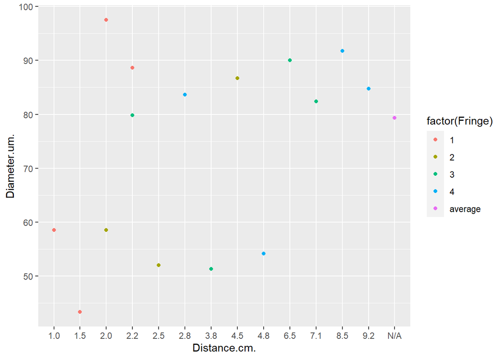

```r
library(ggplot2)
ggplot(diffractiondata, aes(x = Distance.cm., y = Diameter.um.)) +
  geom_point(aes(color = factor(Fringe)))
```

This same comparison can be drawn for the second data frame which brings into question the actually hair colors.

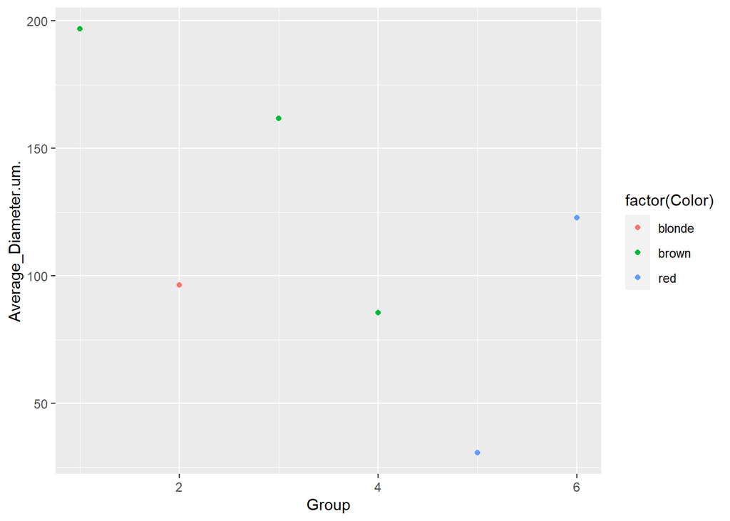

```r
library(ggplot2)
ggplot(averagediameter, aes(x = Group, y = Average_Diameter.um.)) +
  geom_point(aes(color = factor(Color)))
```

This makes it easy to compare which groups worked with which hair color and what their results are compared to each other.

Data can also be observed in line graphs, but only specific data

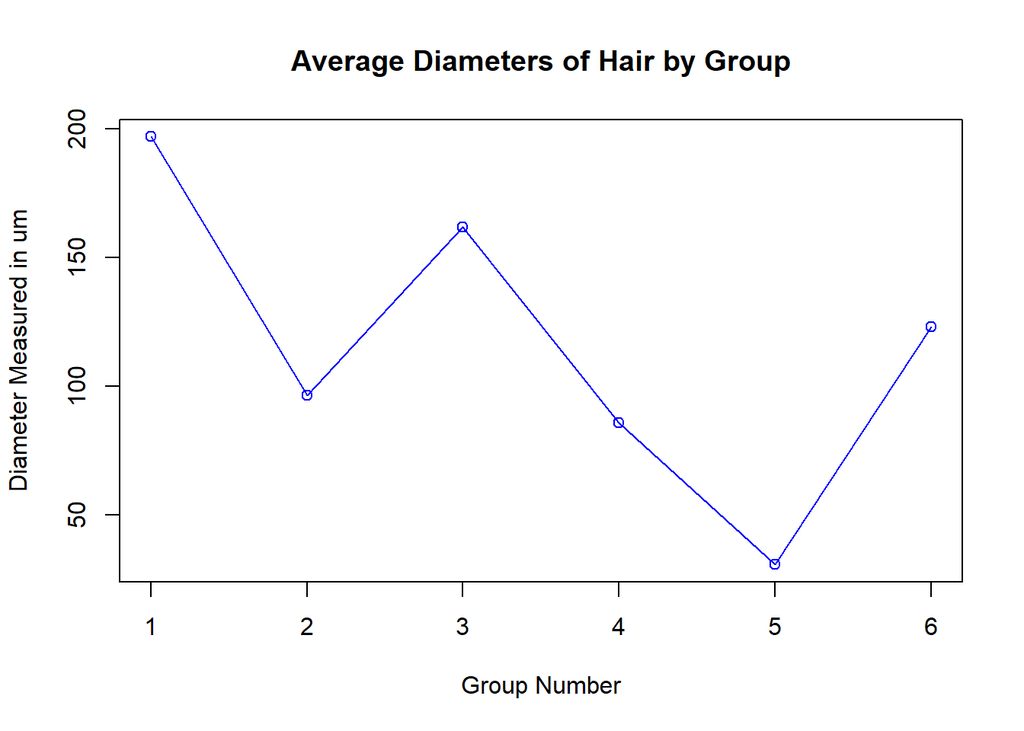

```r
a <- averagediameters
plot(a, type = "o", col = "blue", xlab = "Group Number", ylab = "Diameter Measured in um", main = "Average Diameters of Hair by Group")
```

# Data Tables

Data can be organized in tables

```r
read.csv(file = "DiffractionDataTable1.csv", header = TRUE)
```

```
##    Fringe Diameter Wavelength..nm. Distance..cm.
## 1       1    88.64             650           2.2
## 2       1   975.00             650           2.0
## 3       1    43.33             650           1.5
## 4       1    58.56             640           1.0
## 5       2    86.67             650           4.5
## 6       2    86.67             650           4.5
## 7       2    52.00             650           2.5
## 8       2    58.56             640           2.0
## 9       3    82.39             650           7.1
## 10      3    90.00             650           6.5
## 11      3    51.30             650           3.8
## 12      3    79.85             640           2.2
## 13      4    84.78             650           9.2
## 14      4    91.76             650           8.5
## 15      4    54.16             650           4.8
## 16      4    83.65             640           2.8
```

# Analysis of of Data

Setting up the groups of data At this point we have already set up each of the data strings into a single command. We can take these vectors and create combined groups of them.

```r
fringediameterall <- data.frame(cbind(Firstfringediameterum, Secondfringediameterum, Thirdfringediameterum, Fourthfringediamterum))
fringediameterall
```

```
##   Firstfringediameterum Secondfringediameterum Thirdfringediameterum
## 1                 88.64                  86.67                 82.39
## 2                 97.50                  86.67                 90.00
## 3                 43.33                  52.00                 51.30
## 4                 58.56                  58.56                 79.85
##   Fourthfringediamterum
## 1                 84.78
## 2                 91.76
## 3                 54.16
## 4                 83.65
```

```r
summary(fringediameterall) #This shows the mean, median, minimum, and maximums through each of these data sets.
```

```
##  Firstfringediameterum Secondfringediameterum Thirdfringediameterum
##  Min.   :43.33         Min.   :52.00          Min.   :51.30
##  1st Qu.:54.75         1st Qu.:56.92          1st Qu.:72.71
##  Median :73.60         Median :72.61          Median :81.12
##  Mean   :72.01         Mean   :70.97          Mean   :75.89
##  3rd Qu.:90.86         3rd Qu.:86.67          3rd Qu.:84.29
##  Max.   :97.50         Max.   :86.67          Max.   :90.00
##  Fourthfringediamterum
##  Min.   :54.16
##  1st Qu.:76.28
##  Median :84.22
##  Mean   :78.59
##  3rd Qu.:86.53
##  Max.   :91.76
```

This can be repeated with the average diameter, however we don’t need to put it in a combined group.

```r
summary(averagediameter)
```

```
##      Group      Average_Diameter.um.    Color
##  Min.   :1.00   Min.   : 30.58       blonde:1
##  1st Qu.:2.25   1st Qu.: 88.31       brown :3
##  Median :3.50   Median :109.60       red   :2
##  Mean   :3.50   Mean   :115.66
##  3rd Qu.:4.75   3rd Qu.:152.02
##  Max.   :6.00   Max.   :196.78
```

We can take ANOVAs for each of these data sets as well.

```r
 fringediameter<- stack(fringediameterall)
fringediameter
```

```
##    values                    ind
## 1   88.64  Firstfringediameterum
## 2   97.50  Firstfringediameterum
## 3   43.33  Firstfringediameterum
## 4   58.56  Firstfringediameterum
## 5   86.67 Secondfringediameterum
## 6   86.67 Secondfringediameterum
## 7   52.00 Secondfringediameterum
## 8   58.56 Secondfringediameterum
## 9   82.39  Thirdfringediameterum
## 10  90.00  Thirdfringediameterum
## 11  51.30  Thirdfringediameterum
## 12  79.85  Thirdfringediameterum
## 13  84.78  Fourthfringediamterum
## 14  91.76  Fourthfringediamterum
## 15  54.16  Fourthfringediamterum
## 16  83.65  Fourthfringediamterum
```

```r
Anova_fringediameter <- aov(values ~ ind, data = fringediameter)
summary(Anova_fringediameter)
```

```
##             Df Sum Sq Mean Sq F value Pr(>F)
## ind          3    149    49.6   0.128  0.941
## Residuals   12   4632   386.0
```

## Mathematica

Mathematica is a symbolic mathematical computation program, sometimes called a computer algebra program, used in many scientific, engineering, mathematical, and computing fields. This file will contain the URL for the completed mathematica coding. The data was inputted, plotted, and analyzed by Miranda Plaster until pushed to Git. This URL helps allow this file to be easily viewed in its entirety.URL: https://www.wolframcloud.com/obj/eee32802-7a0e-4018-bc3e-50b66f126d4e

## Python

Python is a multi-paradigm programming language. Many software engineers and researchers use this program because of its code readability and significant white space. In this project, the data was inputted, plotted, and analyzed by Nick Sitter until pushed to Git.

# Inputting the Data

This file was written to code different processes such as calculating averages, creating boxplots, and performing an ANOVA. Notable tables can be seen below.

Table 1. Combined data of all trials completed

diffractiondata = read.table(header=TRUE, text=" Fringe Diameter(um) Wavelength(nm) Distance(cm)  
1 88.64 650 2.2 1 97.5 650 2.0 1 43.33 650 1.5 1 58.56 640 1.0 2 86.67 650 4.5 2 86.67 650 4.5 2 52.00 650 2.5 2 58.56 640 2.0 3 82.39 650 7.1 3 90.0 650 6.5 3 51.3 650 3.8 3 79.85 640 2.2 4 84.78 650 9.2 4 91.76 650 8.5 4 54.16 650 4.8 4 83.65 640 2.8 average 79.32 648 N/A")

Code Block 1 - Averages Diameters of Fringe 1

```python
def avg(numList):
    avg = sum(numList) / len(numList)
    return avg

Fringe1 = [88, 97.5, 43.33, 58.56]
print(avg(Fringe1))
```

```
## 71.8475
```

Code Block 2 - Averages Diameters of Fringe 2

```python
def avg(numList):
    avg = sum(numList) / len(numList)
    return avg

Fringe2 = [86.67, 86.67,52, 58.56]
print(avg(Fringe2))
```

```
## 70.975
```

Code Block 3 - Averages Diameters of Fringe 3

```python
def avg(numList):
    avg = sum(numList) / len(numList)
    return avg

Fringe3 = [82.39, 90, 51.3, 79.85]
print(avg(Fringe3))
```

```
## 75.88499999999999
```

Code Block 4 - Averages Diameters of Fringe 4

```python
def avg(numList):
    avg = sum(numList) / len(numList)
    return avg

Fringe4 = [84.78, 91.76, 54.16, 83.65]
print(avg(Fringe4))
```

```
## 78.5875
```

# Plotting the Data

Code Block 5 - Creates a png File of a Boxplot

```python
import matplotlib as mpl
mpl.use('agg')
import matplotlib.pyplot as plt
Fringe1 = (88, 97.5, 43.33, 58.56)
Fringe2 = (86.67, 86.67,52, 58.56)
Fringe3 = (82.39, 90, 51.3, 79.85)
Fringe4 = (84.78, 91.76, 54.16, 83.65)
data_to_plot = [Fringe1, Fringe2, Fringe3, Fringe4]
fig = plt.figure(1, figsize=(9, 6))
ax = fig.add_subplot(111)
boxplot = ax.boxplot(data_to_plot)
fig.savefig('fig1.png', bbox_inches='tight')
```

# Data Tables

Code Block 6 - Gives ANOVA Table Between The Different Fringes

```python
import statsmodels.api as sm
from statsmodels.formula.api import ols
import pandas as pd
datafile = "DiffractionDataTable1.csv"
data = pd.read_csv(datafile)
mod = ols('Fringe ~ Diameter', data=data).fit()
aov_table = sm.stats.anova_lm(mod, typ=2)
print(aov_table)
```

```
##              sum_sq    df         F    PR(>F)
## Diameter   2.092054   1.0  1.635517  0.221734
## Residual  17.907946  14.0       NaN       NaN
```

## Analysis of R

Overall, R required more code blocks and commands, but gave adequate and professional styled data that was the most useful compared to Python and Mathematica.

## Analysis of Mathematica

The analysis of data from Mathematica was useful, but not as in depth as the R program for data analysis. It contained a list plot and a line plot as visuals to see the data. The list plot is identical to the scatter plot provided in R, but the data is inputted in a more user friendly way with less code lines used. It included listing the data with the distance as the x-coordinate and the diameter as the y-coordinate with sixteen data pairs. The line graph used the same user friendly process, but gave an unusual line in the graph. Mathematica also provided two data tables: diffraction data listed by fringe table and a find anomolies table. These can be useful for a quick analysis, but are not as useful to the R graphs. The t test seemed to function irregularly due to the data in Mathematica and did not provide adequate date. Compared to Python. it has a similar simple language but is more useful for the usage of line plots. Python gives more data regarding the minimum, maximum, and average.

Overall, Mathematic has a simple language that is easy to learn, but provides quick and basic data compared to R. The program’s graphing capability for a visualization of data is more useful for line graphs than Python which provides only a graph with the maximum, medium, and minimum.

## Analysis of Python

Overall, Python is not as useful as R and is more object-oriented. The program does have some benefits such as the minimum, maximum, and average graph compared to Mathematica.

## Conclusion

This project helped me understand each program more in depth with the analysis of data. Each program has supportive functions for analyzing data, but R is the most informative. The use of three programs also helped me learn more about coding, specifically about downloading packages that were needed. Overall, this project helped me understand the importance of programming software.